# Single Layer Neural Network for Regression

# Single Layer NNs

## Installing Keras

We will be using the `keras` engine to fit our neural networks in R. Keras is actually a wrapper around an even more extensive open source platform, TensorFlow, which has also been ported to the R environment. TensorFlow was developed at Google.

If you are on a Mac, its pretty straightforward. In a fresh environment (immediately after starting RStudio), you need to:

- Install the Keras package by typing install.packages(keras)
- Install the backend (including TensorFlow) by typing install_keras() That should be it.

Its a bit more complicated for Windows: In a fresh environment (immediately after starting RStudio), you need to:

- Install the Keras package by typing install.packages(keras)
- Install a simple version of Python. Keras will do this for you if it realizes you don’t have Python installed. To get it to realize this you should
- load the Keras package by typing: library(keras)
- type dataset_mnist(). This should trigger Keras to ask you if you want to install Miniconda or some other scaled down version of Python. Follow the instructions (i.e., start by typing Y) You should now restart R
- Then, install the back-end (including TensorFlow) by typing: install_keras()

## Background

We’ll model the ridership on the Chicago elevated trains as a function of the 14 day lagged ridership at two important stations. This is similar to a dataset we used earlier in the semester, but there is a ton more information here! However, we’re going to be boring and only use 2 predictors.

The two predictors are in the same units (rides per day/1000) and do not need to be normalized.

```r
library(tidymodels)
tidymodels_prefer()
data(Chicago)

Chicago.sub <- Chicago %>% select(ridership, Clark_Lake, Quincy_Wells)

Chicago_split <- initial_time_split(Chicago.sub, prop=.85)
Chicago_train <- training(Chicago_split)
Chicago_test <- testing(Chicago_split)
```

A single-layer NN model specification is done in tidymodels using `mlp`, which stands for “multi-layer perceptron”. The model engine `keras` has 5 tuning parameters (find the 5th in the help file). Since we are considering very simple NNs today, I will set the number of hidden units to something small. And we learned about the ReLU activation, so I will specify that one, though it is not the default.

We will consider next week the optimization algorithms used to fit NNs, which are controlled through a `penalty` and `epochs`. But for today, let’s just set these parameters.

```r
mlp_reg_spec <-
  mlp(hidden_units = 10, activation = "relu",
      # We will discuss more about the fitting of the NN next week. Don't worry about these last two parameters:
      penalty = 0, epochs = 20) %>%
  # This model can be used for classification or regression, so set mode
  set_mode("regression") %>%
  set_engine("keras")
mlp_reg_spec
```

```
## Single Layer Neural Network Model Specification (regression)
##
## Main Arguments:
##   hidden_units = 10
##   penalty = 0
##   epochs = 20
##   activation = relu
##
## Computational engine: keras
```

I am choosing not to do any data preprocessing here. (Why not?)

```r
set.seed(465)
mlp_reg_fit <- mlp_reg_spec %>% fit(ridership ~ ., data = Chicago_train)
mlp_reg_fit
```

```
## parsnip model object
##
## Model: "sequential"
## ________________________________________________________________________________
##  Layer (type)                       Output Shape                    Param #
## ================================================================================
##  dense (Dense)                      (None, 10)                      30
##  dense_1 (Dense)                    (None, 1)                       11
## ================================================================================
## Total params: 41
## Trainable params: 41
## Non-trainable params: 0
## ________________________________________________________________________________
```

```r
Chicago_res <- augment(mlp_reg_fit, new_data = Chicago_test)
```

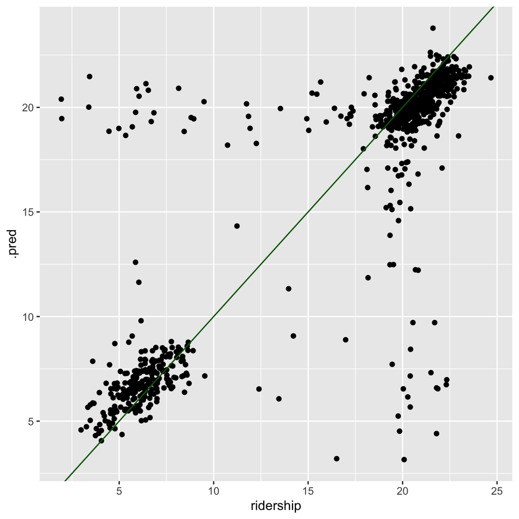

```r
ggplot(Chicago_res) +
  geom_point(aes(ridership, .pred)) +
  geom_abline(slope=1, intercept=0, color="darkgreen")
```

```r
my_metrics <- metric_set(rmse, rsq)
my_metrics(Chicago_res, truth=ridership, estimate=.pred)
```

```
## # A tibble: 2 × 3
##   .metric .estimator .estimate
##   <chr>   <chr>          <dbl>
## 1 rmse    standard       3.40
## 2 rsq     standard       0.758
```